# ps_7

James Hutt

## Question 1: Conduct exploratory data analysis

1A)

Data summary

| Name | Piped data |
| --- | --- |
| Number of rows | 537 |
| Number of columns | 25 |
| _______________________ |  |
| Column type frequency: |  |
| numeric | 2 |
| ________________________ |  |
| Group variables | None |

**Variable type: numeric**

| skim_variable | n_missing | complete_rate | mean | sd | p0 | p25 | p50 | p75 | p100 | hist |
| --- | --- | --- | --- | --- | --- | --- | --- | --- | --- | --- |
| nominate_percentile | 0 | 1 | 50.15 | 28.89 | 0.19 | 25.14 | 50.09 | 75.05 | 100 | ▇▇▇▇▇ |
| age | 0 | 1 | 58.91 | 11.78 | 30.00 | 50.00 | 59.00 | 68.00 | 86 | ▂▅▇▇▂ |

1B)

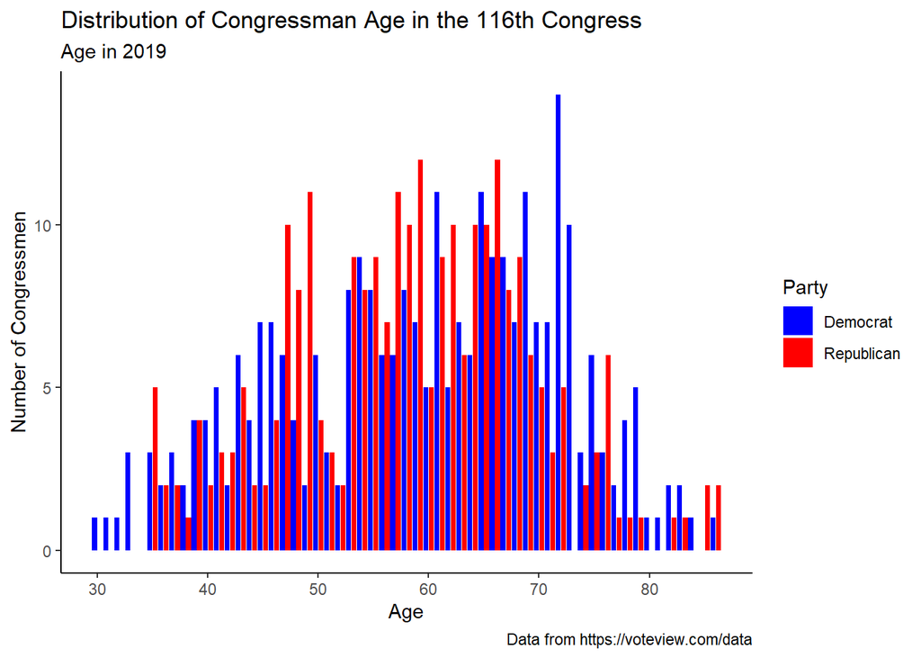

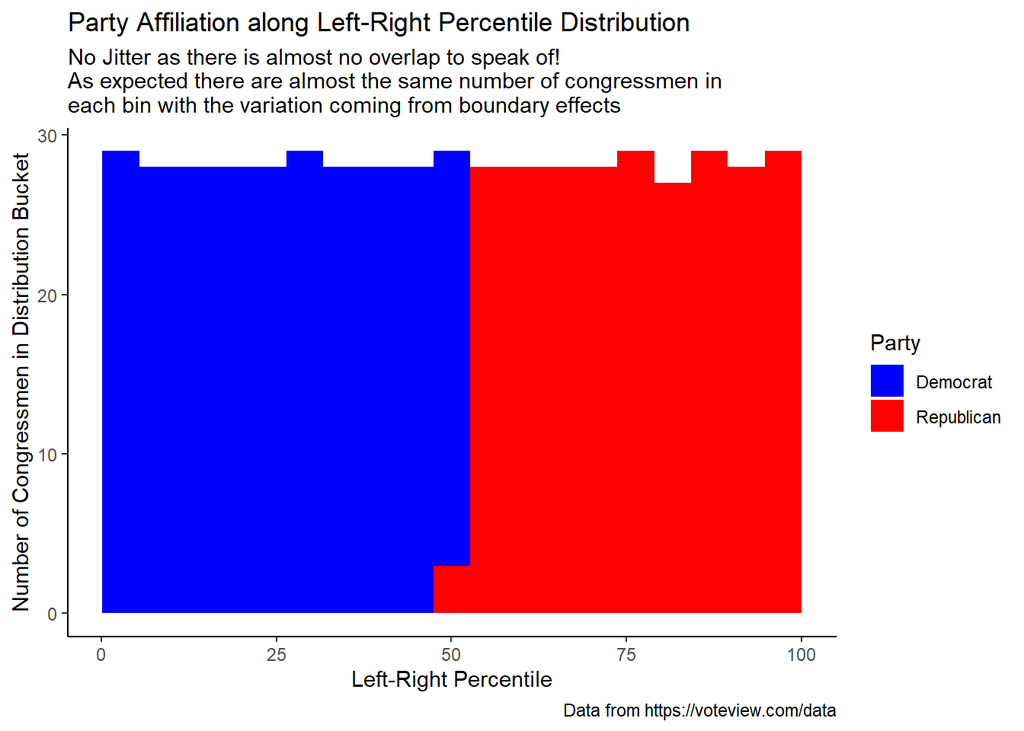

1C) The corrlation coefficient between age and nominate_percentile is -0.1595496. A negative coefficient suggests that the older a member of congress the lower their percentile in the distribution, that is the more liberal they are, whereas a positive coefficient would suggest older members are higher in the percentile range, that is more conservative.

1D)

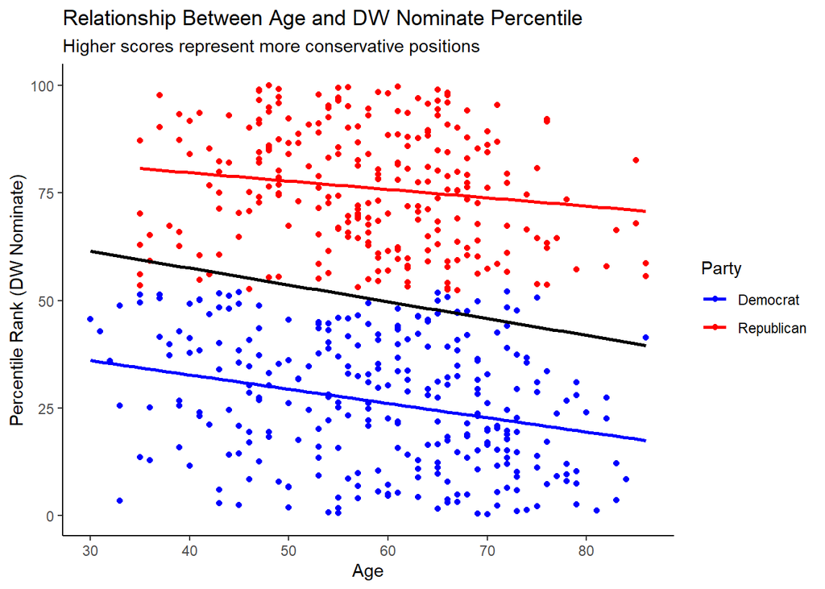

## Question 2: Run a single regression

Effect of Age on DW Nominate Percentile

Higher percentile suggets more conservative

| Variable | Estimate | Lower bound | Upper bound |
| --- | --- | --- | --- |
| (Intercept) | 45.9918180 | 37.7006503 | 54.2829857 |
| age | -0.3321507 | -0.4684586 | -0.1958428 |

2B) The estimated ATE is -0.33. For each year older that a democratic congressman is we expect them to come 0.33 percentage points lower in the distribution of congressmen by DW Nominate. All else equal, if any given congressman were 1y older we would expect 0.33% of their colleagues to switch from being less conservative than them, to more. The correlation is not necessarily causal as the correlation may be a cohort effect. For example, people born in the 50s may consistently be more liberal than people born in the 60s. If this effect is constant over time then age will always be correlated with R-L scale, but the positions of individuals will not change with age as they are not in any way dependent on their age. There is correlation but not causation. Confidence intervals give a measure of uncertainty in our estimate, so we may assess how useful it is. We have only taken one sample, the 116th congress. If we had taken a different sample, say the 115th congress, we may have observed different sample statistics, even though the population level effect, where the population is all democratic congressmen, is unchanged. What we are observing is sampling variation.

2C) If treatment is defined as 1, then a positive coefficient of X would imply an associated increase, on average, of X on the percentile measure. I.e, being in the military moves you, on average, X% points towards the conservative end of the percentile distribution. Since military is 1 or 0 this coefficient is also the average treatment effect which predicts the difference in potential outcomes for the same congressman who either was or was not in the military. This analysis can be considered causal as the randomization should ensure all confounding variables are averaged over treatment and control groups.

## Question 3: Generalize to many regressions

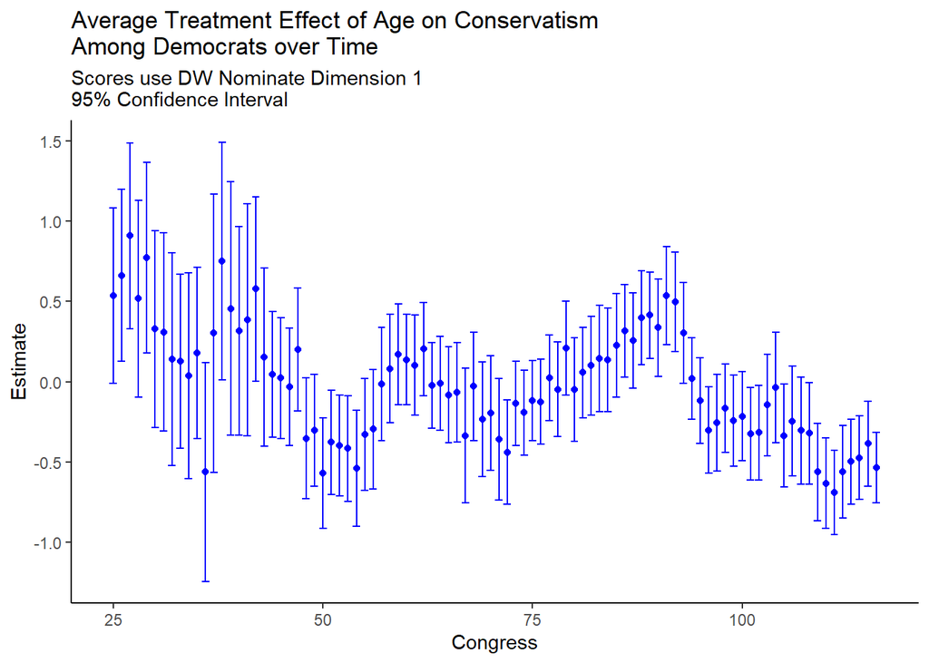